# IODS course project

# Analysis of longitudinal data

First, let´s load the packages used for the exercise.

```r
library(ggplot2)
library(dplyr)
library(tidyr)
library(tidyverse)
library(lme4)
```

In exercise 6 we are using two different datasets, named BPRS and RATS. Both datasets contain repeated measures of different variables in the same subjects during consecutive weeks/days. The variables are related to clinical trials for psychiatric treatments (BPRS) and body weight of rats on different diets for a nutrition study (RATS).

```r
BPRSL <- read.csv("BPRSL.csv")
RATSL <- read.csv("RATSL.csv")
```

We will start with the **RATS dataset** in long format, implementing the **analyses of chapter 8** in MABS.

```r
RATSL$ID <- factor(RATSL$ID)
RATSL$Group <- factor(RATSL$Group)
summary(RATSL)
```

```
##        X                ID      Group     weeks                bprs
##  Min.   :  1.00   1      : 11   1:88   Length:176         Min.   :225.0
##  1st Qu.: 44.75   2      : 11   2:44   Class :character   1st Qu.:267.0
##  Median : 88.50   3      : 11   3:44   Mode  :character   Median :344.5
##  Mean   : 88.50   4      : 11                             Mean   :384.5
##  3rd Qu.:132.25   5      : 11                             3rd Qu.:511.2
##  Max.   :176.00   6      : 11                             Max.   :628.0
##                   (Other):110
##       Time
##  Min.   :1.000
##  1st Qu.:2.000
##  Median :4.000
##  Mean   :3.727
##  3rd Qu.:5.000
##  Max.   :8.000
##
```

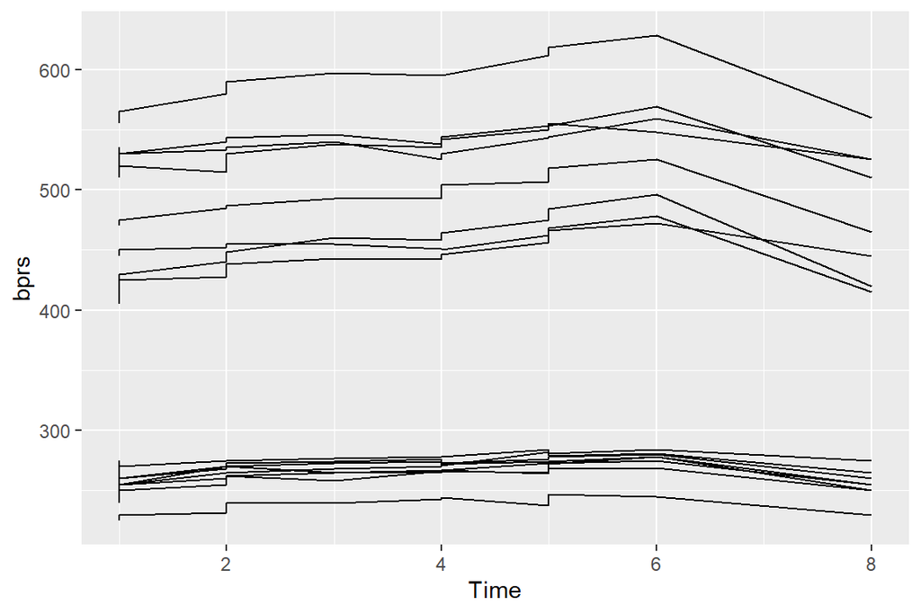

```r
  ggplot(RATSL, aes(x = Time, y = bprs, group = ID)) +
    geom_line()
```

The individuals are divided according to which diet group they belong to. It seems that individuals on diet group 1 have a much lower bprs, whereas between groups 2 and 3 the difference in bprs is less pronounced. In all the groups, bprs seems to slightly decrease at the end of the treatment (diet).

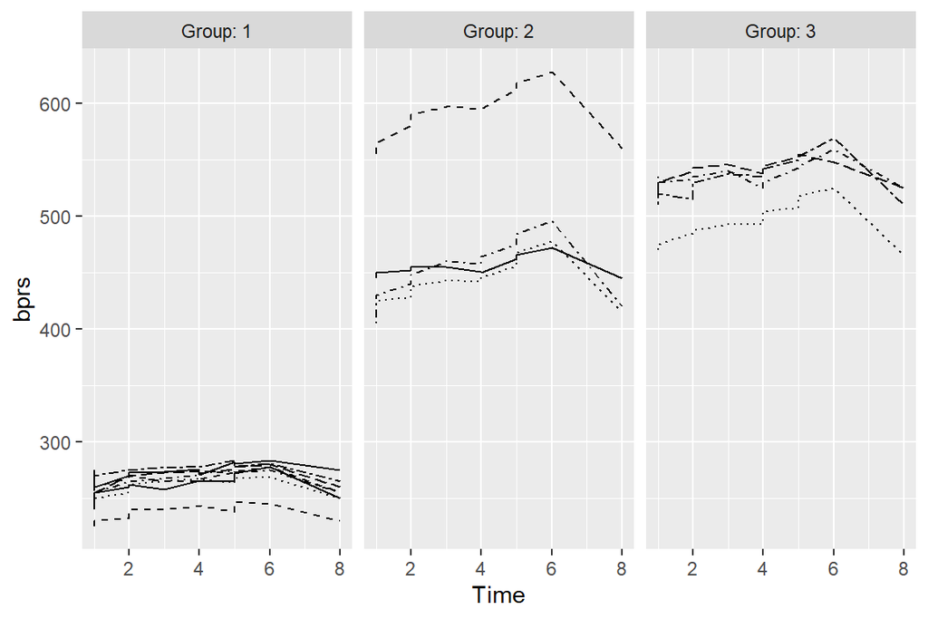

```r
  ggplot(RATSL, aes(x = Time, y = bprs, linetype = ID)) +
    geom_line() +
    scale_linetype_manual(values = rep(1:10, times=4)) +
    facet_grid(. ~ Group, labeller = label_both) +
    theme(legend.position = "none") +
    scale_y_continuous(limits = c(min(RATSL$bprs), max(RATSL$bprs)))
```

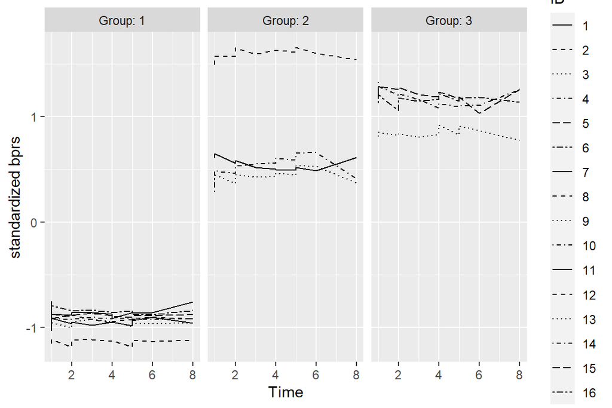

```r
  RATSL2 <- RATSL %>%
    group_by(Time) %>%
    mutate(stdbprs = (bprs - mean(bprs))/sd(bprs)) %>%
    ungroup()

  ggplot(RATSL2, aes(x = Time, y = stdbprs, linetype = ID)) +
    geom_line() +
    scale_linetype_manual(values = rep(1:10, times=4)) +
    facet_grid(. ~ Group, labeller = label_both) +
    scale_y_continuous(name = "standardized bprs")
```

The bprs values change after **standardizing** them. Surprisingly, the new plots reveal that in some cases the bprs increases instead of decreasing at the end of the treatment or diet (i.e. individual 1 in group 1).

In the following plot, the repeated measurements for each individual have been transformed into a single value using the **summary measure method**. The plot shows the mean response of the subjects under the three different diets, as well as the standard errors of those means.

```r
n <- RATSL$Time %>% unique() %>% length()

  RATSS <- RATSL %>%
    group_by(Group, Time) %>%
    summarise(mean = mean(bprs), se = sd(bprs)/sqrt(n)) %>%
    ungroup()
```

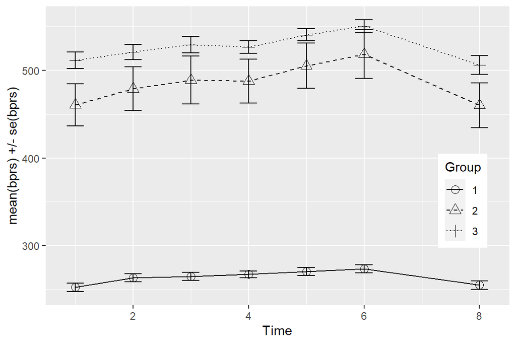

```r
  ggplot(RATSS, aes(x = Time, y = mean, linetype = Group, shape = Group)) +
    geom_line() +
    scale_linetype_manual(values = c(1,2,3)) +
    geom_point(size=3) +
    scale_shape_manual(values = c(1,2,3)) +
    geom_errorbar(aes(ymin=mean-se, ymax=mean+se, linetype="1"), width=0.3) +
    theme(legend.position = c(0.9,0.35)) +
    scale_y_continuous(name = "mean(bprs) +/- se(bprs)")
```

```r
  RATSS8S <- RATSL %>%
    group_by(Group, ID) %>%
    summarise(mean = mean(bprs)) %>%
    ungroup()
```

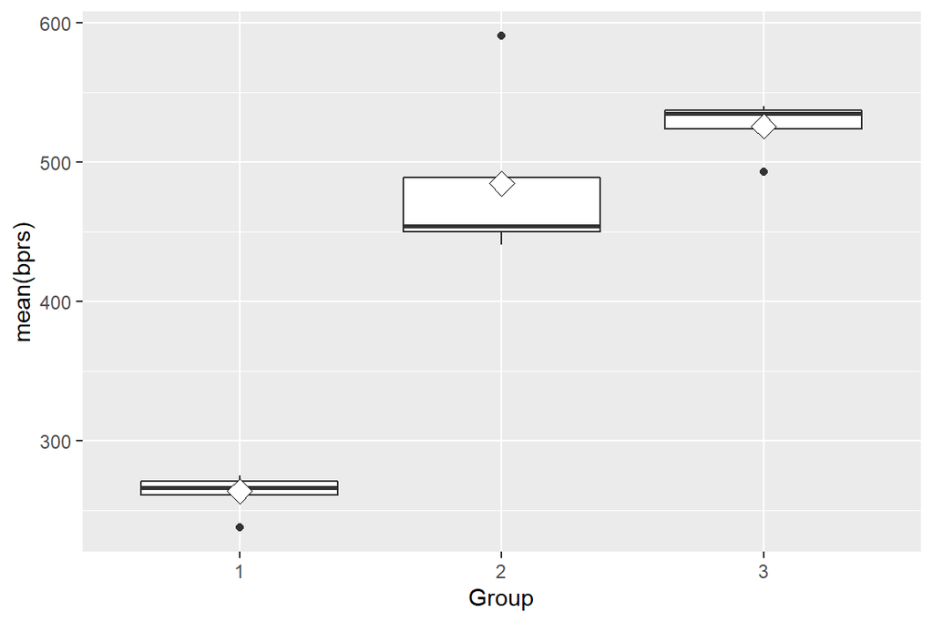

```r
  ggplot(RATSS8S, aes(x = Group, y = mean)) +
    geom_boxplot() +
    stat_summary(fun.y = "mean", geom = "point", shape=23, size=4, fill = "white") +
    scale_y_continuous(name = "mean(bprs)")
```

The previous boxplot shows the mean values of bprs for each one of the diet groups, as well as the data quartiles. It is possible to observe the presence of **outliers** (marked with a dot in the plot) in all the groups.

Regarding the **t.test** applied in the chapter 8 of the book, it is not possible to perform it in the RATS dataset, as the levels of the variable Groups are > 2. In this case an ANOVA would be more appropriate. In addition, there is no pre-treatment level in the dataset, so no baseline for the comparison of variances and means.

Now let´s move to the analyses in **chapter 9** of the book. For those, we will use the **BPRS dataset** in the long form. First, wee need to convert to factor some of the variables.

```r
BPRSL <- read.csv("BPRSL.csv")

BPRSL$treatment <- factor(BPRSL$treatment)
BPRSL$subject <- factor(BPRSL$subject)
```

Once the variables are transformed, we can fit a linear regression model to check which variables help to explain the variance of *bprs*. According to the fitted model, *week* is significant but *treatment2* is not. The variables explain about 18% of the variance of *bprs*.

```r
BPRSL_lm <- lm(bprs ~ week + treatment, data = BPRSL)
  summary(BPRSL_lm)
```

```
##
## Call:
## lm(formula = bprs ~ week + treatment, data = BPRSL)
##
## Residuals:
##     Min      1Q  Median      3Q     Max
## -22.454  -8.965  -3.196   7.002  50.244
##
## Coefficients:
##             Estimate Std. Error t value Pr(>|t|)
## (Intercept)  46.4539     1.3670  33.982   <2e-16 ***
## week         -2.2704     0.2524  -8.995   <2e-16 ***
## treatment2    0.5722     1.3034   0.439    0.661
## ---
## Signif. codes:  0 '***' 0.001 '**' 0.01 '*' 0.05 '.' 0.1 ' ' 1
##
## Residual standard error: 12.37 on 357 degrees of freedom
## Multiple R-squared:  0.1851, Adjusted R-squared:  0.1806
## F-statistic: 40.55 on 2 and 357 DF,  p-value: < 2.2e-16
```

After this, we can proceed to fit a **linear mixed effects models**. In this model, we include the random effects term, allowing the linear regression fit for each subject to differ in intercept from other subjects. In our model, the response variable is *bprs* and the independent variables are *week* and *treatment*.

```r
  BPRSL_ref <- lmer(bprs ~ week + treatment + (1 | subject), data = BPRSL, REML = FALSE)
  summary(BPRSL_ref)
```

```
## Linear mixed model fit by maximum likelihood  ['lmerMod']
## Formula: bprs ~ week + treatment + (1 | subject)
##    Data: BPRSL
##
##      AIC      BIC   logLik deviance df.resid
##   2748.7   2768.1  -1369.4   2738.7      355
##
## Scaled residuals:
##     Min      1Q  Median      3Q     Max
## -3.0481 -0.6749 -0.1361  0.4813  3.4855
##
## Random effects:
##  Groups   Name        Variance Std.Dev.
##  subject  (Intercept)  47.41    6.885
##  Residual             104.21   10.208
## Number of obs: 360, groups:  subject, 20
##
## Fixed effects:
##             Estimate Std. Error t value
## (Intercept)  46.4539     1.9090  24.334
## week         -2.2704     0.2084 -10.896
## treatment2    0.5722     1.0761   0.532
##
## Correlation of Fixed Effects:
##            (Intr) week
## week       -0.437
## treatment2 -0.282  0.000
```

Next is to fit a **random intercept and random slope model**. This allows the the linear regression fit to differ not only in intercept for each subject but also in slope. Therefore, the model accounts for the individual differences in the subjects profiles and the effect of passing weeks.

```r
BPRSL_ref1 <- lmer(bprs ~ week + treatment + (week | subject), data = BPRSL, REML = FALSE)
  summary(BPRSL_ref1)
```

```
## Linear mixed model fit by maximum likelihood  ['lmerMod']
## Formula: bprs ~ week + treatment + (week | subject)
##    Data: BPRSL
##
##      AIC      BIC   logLik deviance df.resid
##   2745.4   2772.6  -1365.7   2731.4      353
##
## Scaled residuals:
##     Min      1Q  Median      3Q     Max
## -2.8919 -0.6194 -0.0691  0.5531  3.7976
##
## Random effects:
##  Groups   Name        Variance Std.Dev. Corr
##  subject  (Intercept) 64.8222  8.0512
##           week         0.9609  0.9802   -0.51
##  Residual             97.4305  9.8707
## Number of obs: 360, groups:  subject, 20
##
## Fixed effects:
##             Estimate Std. Error t value
## (Intercept)  46.4539     2.1052  22.066
## week         -2.2704     0.2977  -7.626
## treatment2    0.5722     1.0405   0.550
##
## Correlation of Fixed Effects:
##            (Intr) week
## week       -0.582
## treatment2 -0.247  0.000
```

```r
anova(BPRSL_ref1, BPRSL_ref)
```

```
## Data: BPRSL
## Models:
## BPRSL_ref: bprs ~ week + treatment + (1 | subject)
## BPRSL_ref1: bprs ~ week + treatment + (week | subject)
##            npar    AIC    BIC  logLik deviance  Chisq Df Pr(>Chisq)
## BPRSL_ref     5 2748.7 2768.1 -1369.4   2738.7
## BPRSL_ref1    7 2745.4 2772.6 -1365.7   2731.4 7.2721  2    0.02636 *
## ---
## Signif. codes:  0 '***' 0.001 '**' 0.01 '*' 0.05 '.' 0.1 ' ' 1
```

In this model we can also include **interactions**. Following there is a new model which considers the interaction between *week* and *treatment*.

```r
BPRSL_ref2 <- lmer(bprs ~ week + treatment + (week | subject) + week*treatment, data = BPRSL, REML = FALSE)
  summary(BPRSL_ref2)
```

```
## Linear mixed model fit by maximum likelihood  ['lmerMod']
## Formula: bprs ~ week + treatment + (week | subject) + week * treatment
##    Data: BPRSL
##
##      AIC      BIC   logLik deviance df.resid
##   2744.3   2775.4  -1364.1   2728.3      352
##
## Scaled residuals:
##     Min      1Q  Median      3Q     Max
## -3.0512 -0.6271 -0.0768  0.5288  3.9260
##
## Random effects:
##  Groups   Name        Variance Std.Dev. Corr
##  subject  (Intercept) 64.9964  8.0620
##           week         0.9687  0.9842   -0.51
##  Residual             96.4707  9.8220
## Number of obs: 360, groups:  subject, 20
##
## Fixed effects:
##                 Estimate Std. Error t value
## (Intercept)      47.8856     2.2521  21.262
## week             -2.6283     0.3589  -7.323
## treatment2       -2.2911     1.9090  -1.200
## week:treatment2   0.7158     0.4010   1.785
##
## Correlation of Fixed Effects:
##             (Intr) week   trtmn2
## week        -0.650
## treatment2  -0.424  0.469
## wek:trtmnt2  0.356 -0.559 -0.840
```

Again, we can compare with and **ANOVA** if the model has improved after including the interaction.

```r
anova(BPRSL_ref2, BPRSL_ref1)
```

```
## Data: BPRSL
## Models:
## BPRSL_ref1: bprs ~ week + treatment + (week | subject)
## BPRSL_ref2: bprs ~ week + treatment + (week | subject) + week * treatment
##            npar    AIC    BIC  logLik deviance  Chisq Df Pr(>Chisq)
## BPRSL_ref1    7 2745.4 2772.6 -1365.7   2731.4
## BPRSL_ref2    8 2744.3 2775.4 -1364.1   2728.3 3.1712  1    0.07495 .
## ---
## Signif. codes:  0 '***' 0.001 '**' 0.01 '*' 0.05 '.' 0.1 ' ' 1
```

According to the ANOVA, there is no significant improvement (p-value = 0.07495) when the interaction term is included. We can add the fitted values to our dataset and plot them against the observed bprs values. In the next plot, the values represent the two different treatment groups.

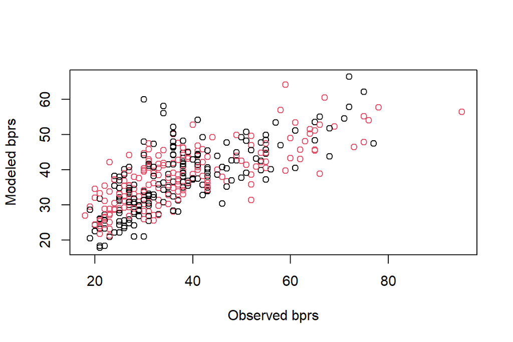

```r
BPRSL$fitted <- fitted(BPRSL_ref2)
    plot(BPRSL$bprs, BPRSL$fitted, xlab="Observed bprs", ylab="Modeled bprs", col = BPRSL$treatment)
```

Unfortunately, I was not able to produce the two separate plots comparing observed vs fitted values, as there was a problem with setting the linetype aesthetics in ggplot. So I decided to plot the values using Rbase.

(more chapters to be added similarly as we proceed with the course!)